# Risk Factor Analysis

## Outcome Variable

**Outcome Variable:** stunted

## Predictor Variables

**Intervention Variable:** mwtkg

**Adjustment Set:**

- arm
- W_mage
- W_fage
- meducyrs
- feducyrs
- single
- brthmon
- delta_W_mage
- delta_W_fage
- delta_meducyrs
- delta_feducyrs
- delta_single
- delta_brthmon

## Stratifying Variables

The analysis was stratified on these variable(s):

- agecat
- studyid
- country

## Data Summary

| agecat | studyid | country | mwtkg | stunted | n_cell | n |
| --- | --- | --- | --- | --- | --- | --- |
| Birth | ki0047075b-MAL-ED | BANGLADESH | >=57.5 | 0 | 43 | 246 |
| Birth | ki0047075b-MAL-ED | BANGLADESH | >=57.5 | 1 | 7 | 246 |
| Birth | ki0047075b-MAL-ED | BANGLADESH | <42.5 | 0 | 44 | 246 |
| Birth | ki0047075b-MAL-ED | BANGLADESH | <42.5 | 1 | 9 | 246 |
| Birth | ki0047075b-MAL-ED | BANGLADESH | [42.5-50) | 0 | 68 | 246 |
| Birth | ki0047075b-MAL-ED | BANGLADESH | [42.5-50) | 1 | 17 | 246 |
| Birth | ki0047075b-MAL-ED | BANGLADESH | [50-57.5) | 0 | 49 | 246 |
| Birth | ki0047075b-MAL-ED | BANGLADESH | [50-57.5) | 1 | 9 | 246 |
| 6 months | ki0047075b-MAL-ED | BANGLADESH | >=57.5 | 0 | 43 | 241 |
| 6 months | ki0047075b-MAL-ED | BANGLADESH | >=57.5 | 1 | 6 | 241 |
| 6 months | ki0047075b-MAL-ED | BANGLADESH | <42.5 | 0 | 39 | 241 |
| 6 months | ki0047075b-MAL-ED | BANGLADESH | <42.5 | 1 | 15 | 241 |
| 6 months | ki0047075b-MAL-ED | BANGLADESH | [42.5-50) | 0 | 60 | 241 |
| 6 months | ki0047075b-MAL-ED | BANGLADESH | [42.5-50) | 1 | 23 | 241 |
| 6 months | ki0047075b-MAL-ED | BANGLADESH | [50-57.5) | 0 | 54 | 241 |
| 6 months | ki0047075b-MAL-ED | BANGLADESH | [50-57.5) | 1 | 1 | 241 |
| 24 months | ki0047075b-MAL-ED | BANGLADESH | >=57.5 | 0 | 32 | 212 |
| 24 months | ki0047075b-MAL-ED | BANGLADESH | >=57.5 | 1 | 11 | 212 |
| 24 months | ki0047075b-MAL-ED | BANGLADESH | <42.5 | 0 | 13 | 212 |
| 24 months | ki0047075b-MAL-ED | BANGLADESH | <42.5 | 1 | 32 | 212 |
| 24 months | ki0047075b-MAL-ED | BANGLADESH | [42.5-50) | 0 | 32 | 212 |
| 24 months | ki0047075b-MAL-ED | BANGLADESH | [42.5-50) | 1 | 41 | 212 |
| 24 months | ki0047075b-MAL-ED | BANGLADESH | [50-57.5) | 0 | 37 | 212 |
| 24 months | ki0047075b-MAL-ED | BANGLADESH | [50-57.5) | 1 | 14 | 212 |
| Birth | ki0047075b-MAL-ED | BRAZIL | >=57.5 | 0 | 111 | 184 |
| Birth | ki0047075b-MAL-ED | BRAZIL | >=57.5 | 1 | 11 | 184 |
| Birth | ki0047075b-MAL-ED | BRAZIL | <42.5 | 0 | 9 | 184 |
| Birth | ki0047075b-MAL-ED | BRAZIL | <42.5 | 1 | 3 | 184 |
| Birth | ki0047075b-MAL-ED | BRAZIL | [42.5-50) | 0 | 11 | 184 |
| Birth | ki0047075b-MAL-ED | BRAZIL | [42.5-50) | 1 | 2 | 184 |

[output cut: 296 more lines]

The following strata were considered:

- agecat: 24 months, studyid: ki0047075b-MAL-ED, country: BANGLADESH
- agecat: 24 months, studyid: ki0047075b-MAL-ED, country: BRAZIL
- agecat: 24 months, studyid: ki0047075b-MAL-ED, country: INDIA
- agecat: 24 months, studyid: ki0047075b-MAL-ED, country: NEPAL
- agecat: 24 months, studyid: ki0047075b-MAL-ED, country: PERU
- agecat: 24 months, studyid: ki0047075b-MAL-ED, country: SOUTH AFRICA
- agecat: 24 months, studyid: ki0047075b-MAL-ED, country: TANZANIA, UNITED REPUBLIC OF
- agecat: 24 months, studyid: ki1017093-NIH-Birth, country: BANGLADESH
- agecat: 24 months, studyid: ki1017093b-PROVIDE, country: BANGLADESH
- agecat: 24 months, studyid: ki1017093c-NIH-Crypto, country: BANGLADESH
- agecat: 24 months, studyid: ki1066203-TanzaniaChild2, country: TANZANIA, UNITED REPUBLIC OF
- agecat: 24 months, studyid: ki1119695-PROBIT, country: BELARUS
- agecat: 24 months, studyid: ki1126311-ZVITAMBO, country: ZIMBABWE
- agecat: 24 months, studyid: ki1148112-LCNI-5, country: MALAWI
- agecat: 6 months, studyid: ki0047075b-MAL-ED, country: BANGLADESH
- agecat: 6 months, studyid: ki0047075b-MAL-ED, country: BRAZIL
- agecat: 6 months, studyid: ki0047075b-MAL-ED, country: INDIA
- agecat: 6 months, studyid: ki0047075b-MAL-ED, country: NEPAL
- agecat: 6 months, studyid: ki0047075b-MAL-ED, country: PERU
- agecat: 6 months, studyid: ki0047075b-MAL-ED, country: SOUTH AFRICA
- agecat: 6 months, studyid: ki0047075b-MAL-ED, country: TANZANIA, UNITED REPUBLIC OF
- agecat: 6 months, studyid: ki1000304b-SAS-CompFeed, country: INDIA
- agecat: 6 months, studyid: ki1017093-NIH-Birth, country: BANGLADESH
- agecat: 6 months, studyid: ki1017093b-PROVIDE, country: BANGLADESH
- agecat: 6 months, studyid: ki1017093c-NIH-Crypto, country: BANGLADESH
- agecat: 6 months, studyid: ki1066203-TanzaniaChild2, country: TANZANIA, UNITED REPUBLIC OF
- agecat: 6 months, studyid: ki1119695-PROBIT, country: BELARUS
- agecat: 6 months, studyid: ki1126311-ZVITAMBO, country: ZIMBABWE
- agecat: 6 months, studyid: ki1148112-LCNI-5, country: MALAWI
- agecat: Birth, studyid: ki0047075b-MAL-ED, country: BANGLADESH
- agecat: Birth, studyid: ki0047075b-MAL-ED, country: BRAZIL
- agecat: Birth, studyid: ki0047075b-MAL-ED, country: INDIA
- agecat: Birth, studyid: ki0047075b-MAL-ED, country: NEPAL
- agecat: Birth, studyid: ki0047075b-MAL-ED, country: PERU
- agecat: Birth, studyid: ki0047075b-MAL-ED, country: SOUTH AFRICA
- agecat: Birth, studyid: ki0047075b-MAL-ED, country: TANZANIA, UNITED REPUBLIC OF
- agecat: Birth, studyid: ki1000304b-SAS-CompFeed, country: INDIA
- agecat: Birth, studyid: ki1017093-NIH-Birth, country: BANGLADESH
- agecat: Birth, studyid: ki1017093c-NIH-Crypto, country: BANGLADESH
- agecat: Birth, studyid: ki1119695-PROBIT, country: BELARUS
- agecat: Birth, studyid: ki1126311-ZVITAMBO, country: ZIMBABWE

### Dropped Strata

Some strata were dropped due to rare outcomes:

- agecat: 6 months, studyid: ki0047075b-MAL-ED, country: BANGLADESH
- agecat: Birth, studyid: ki0047075b-MAL-ED, country: BRAZIL
- agecat: 6 months, studyid: ki0047075b-MAL-ED, country: BRAZIL
- agecat: 24 months, studyid: ki0047075b-MAL-ED, country: BRAZIL
- agecat: Birth, studyid: ki0047075b-MAL-ED, country: INDIA
- agecat: 6 months, studyid: ki0047075b-MAL-ED, country: NEPAL
- agecat: 24 months, studyid: ki0047075b-MAL-ED, country: NEPAL
- agecat: Birth, studyid: ki0047075b-MAL-ED, country: NEPAL
- agecat: Birth, studyid: ki0047075b-MAL-ED, country: PERU
- agecat: Birth, studyid: ki0047075b-MAL-ED, country: SOUTH AFRICA
- agecat: 6 months, studyid: ki0047075b-MAL-ED, country: SOUTH AFRICA
- agecat: 24 months, studyid: ki0047075b-MAL-ED, country: SOUTH AFRICA
- agecat: Birth, studyid: ki0047075b-MAL-ED, country: TANZANIA, UNITED REPUBLIC OF
- agecat: 6 months, studyid: ki0047075b-MAL-ED, country: TANZANIA, UNITED REPUBLIC OF
- agecat: 24 months, studyid: ki0047075b-MAL-ED, country: TANZANIA, UNITED REPUBLIC OF
- agecat: Birth, studyid: ki1000304b-SAS-CompFeed, country: INDIA
- agecat: Birth, studyid: ki1017093-NIH-Birth, country: BANGLADESH
- agecat: Birth, studyid: ki1017093c-NIH-Crypto, country: BANGLADESH
- agecat: 6 months, studyid: ki1066203-TanzaniaChild2, country: TANZANIA, UNITED REPUBLIC OF
- agecat: 24 months, studyid: ki1066203-TanzaniaChild2, country: TANZANIA, UNITED REPUBLIC OF
- agecat: Birth, studyid: ki1119695-PROBIT, country: BELARUS
- agecat: 24 months, studyid: ki1119695-PROBIT, country: BELARUS
- agecat: 24 months, studyid: ki1126311-ZVITAMBO, country: ZIMBABWE

## Methods Detail

We’re interested in the causal parameters $E[Y_a]$ for all values of $a \in \mathcal{A}$. These parameters represent the mean outcome if, possibly contrary to fact, we intervened to set all units to have $A=a$. Under the randomization and positivity assumptions, these are identified by the statistical parameters $\psi_a=E_W[E_{Y|A,W}(Y|A=a,W)]$. In addition, we’re interested in the mean of $Y$, $E[Y]$ under no intervention (the observed mean). We will estimate these parameters by using SuperLearner to fit the relevant likelihood factors – $E_{Y|A,W}(Y|A=a,W)$ and $p(A=a|W)$, and then updating our likelihood fit using a joint TMLE.

For unadjusted analyses ($W=\{\}$), initial likelihoods were estimated using Lrnr_glm to estimate the simple $E(Y|A)$ and Lrnr_mean to estimate $p(A)$. For adjusted analyses, a small library containing Lrnr_glmnet, Lrnr_xgboost, and Lrnr_mean was used.

Having estimated these parameters, we will then use the delta method to estimate relative risks and attributable risks relative to a prespecified baseline level of $A$.

# Results Detail

## Results Plots

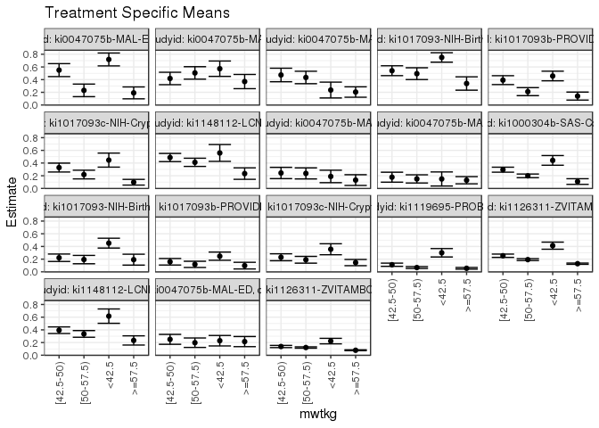

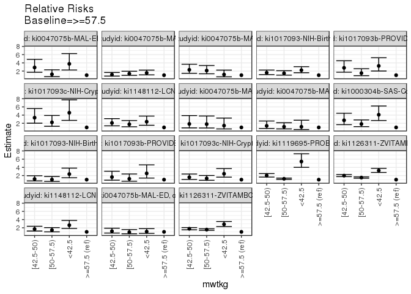

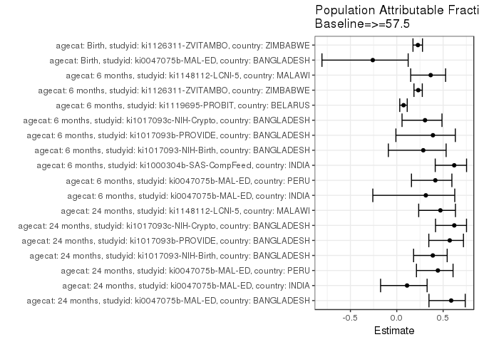

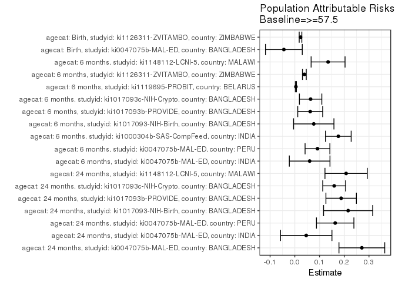

## Results Table

### Parameter: TSM

| agecat | studyid | country | intervention_level | baseline_level | estimate | ci_lower | ci_upper |
| --- | --- | --- | --- | --- | --- | --- | --- |
| Birth | ki0047075b-MAL-ED | BANGLADESH | >=57.5 | NA | 0.2149411 | 0.1349674 | 0.2949148 |
| Birth | ki0047075b-MAL-ED | BANGLADESH | <42.5 | NA | 0.2289434 | 0.1465863 | 0.3113006 |
| Birth | ki0047075b-MAL-ED | BANGLADESH | [42.5-50) | NA | 0.2504916 | 0.1721714 | 0.3288119 |
| Birth | ki0047075b-MAL-ED | BANGLADESH | [50-57.5) | NA | 0.1974191 | 0.1231078 | 0.2717303 |
| Birth | ki1126311-ZVITAMBO | ZIMBABWE | >=57.5 | NA | 0.0782080 | 0.0713789 | 0.0850371 |
| Birth | ki1126311-ZVITAMBO | ZIMBABWE | <42.5 | NA | 0.2230182 | 0.1793244 | 0.2667119 |
| Birth | ki1126311-ZVITAMBO | ZIMBABWE | [42.5-50) | NA | 0.1372758 | 0.1199319 | 0.1546197 |
| Birth | ki1126311-ZVITAMBO | ZIMBABWE | [50-57.5) | NA | 0.1214684 | 0.1106522 | 0.1322846 |
| 6 months | ki0047075b-MAL-ED | INDIA | >=57.5 | NA | 0.1314770 | 0.0467648 | 0.2161893 |
| 6 months | ki0047075b-MAL-ED | INDIA | <42.5 | NA | 0.1885454 | 0.0904906 | 0.2866003 |
| 6 months | ki0047075b-MAL-ED | INDIA | [42.5-50) | NA | 0.2433431 | 0.1543801 | 0.3323062 |
| 6 months | ki0047075b-MAL-ED | INDIA | [50-57.5) | NA | 0.2366394 | 0.1494251 | 0.3238537 |
| 6 months | ki0047075b-MAL-ED | PERU | >=57.5 | NA | 0.1288867 | 0.0722745 | 0.1854990 |
| 6 months | ki0047075b-MAL-ED | PERU | <42.5 | NA | 0.1488168 | 0.0382032 | 0.2594305 |
| 6 months | ki0047075b-MAL-ED | PERU | [42.5-50) | NA | 0.1770319 | 0.0987009 | 0.2553630 |
| 6 months | ki0047075b-MAL-ED | PERU | [50-57.5) | NA | 0.1500798 | 0.0854321 | 0.2147274 |
| 6 months | ki1000304b-SAS-CompFeed | INDIA | >=57.5 | NA | 0.1081376 | 0.0637356 | 0.1525396 |
| 6 months | ki1000304b-SAS-CompFeed | INDIA | <42.5 | NA | 0.4418568 | 0.3655382 | 0.5181754 |
| 6 months | ki1000304b-SAS-CompFeed | INDIA | [42.5-50) | NA | 0.2953222 | 0.2561703 | 0.3344741 |
| 6 months | ki1000304b-SAS-CompFeed | INDIA | [50-57.5) | NA | 0.1978580 | 0.1686897 | 0.2270264 |
| 6 months | ki1017093-NIH-Birth | BANGLADESH | >=57.5 | NA | 0.1915381 | 0.1056664 | 0.2774098 |
| 6 months | ki1017093-NIH-Birth | BANGLADESH | <42.5 | NA | 0.4520186 | 0.3746078 | 0.5294294 |
| 6 months | ki1017093-NIH-Birth | BANGLADESH | [42.5-50) | NA | 0.2216788 | 0.1632116 | 0.2801460 |
| 6 months | ki1017093-NIH-Birth | BANGLADESH | [50-57.5) | NA | 0.1932138 | 0.1273367 | 0.2590910 |
| 6 months | ki1017093b-PROVIDE | BANGLADESH | >=57.5 | NA | 0.0974663 | 0.0449966 | 0.1499360 |
| 6 months | ki1017093b-PROVIDE | BANGLADESH | <42.5 | NA | 0.2466129 | 0.1821034 | 0.3111225 |
| 6 months | ki1017093b-PROVIDE | BANGLADESH | [42.5-50) | NA | 0.1586419 | 0.1070581 | 0.2102257 |
| 6 months | ki1017093b-PROVIDE | BANGLADESH | [50-57.5) | NA | 0.1174887 | 0.0684005 | 0.1665770 |
| 6 months | ki1017093c-NIH-Crypto | BANGLADESH | >=57.5 | NA | 0.1458687 | 0.0966710 | 0.1950664 |
| 6 months | ki1017093c-NIH-Crypto | BANGLADESH | <42.5 | NA | 0.3557373 | 0.2692700 | 0.4422046 |
| 6 months | ki1017093c-NIH-Crypto | BANGLADESH | [42.5-50) | NA | 0.2294405 | 0.1748090 | 0.2840720 |
| 6 months | ki1017093c-NIH-Crypto | BANGLADESH | [50-57.5) | NA | 0.1898592 | 0.1364424 | 0.2432760 |
| 6 months | ki1119695-PROBIT | BELARUS | >=57.5 | NA | 0.0554587 | 0.0424143 | 0.0685032 |
| 6 months | ki1119695-PROBIT | BELARUS | <42.5 | NA | 0.3002135 | 0.2339858 | 0.3664413 |
| 6 months | ki1119695-PROBIT | BELARUS | [42.5-50) | NA | 0.1115655 | 0.0862701 | 0.1368610 |
| 6 months | ki1119695-PROBIT | BELARUS | [50-57.5) | NA | 0.0671045 | 0.0525583 | 0.0816507 |
| 6 months | ki1126311-ZVITAMBO | ZIMBABWE | >=57.5 | NA | 0.1282042 | 0.1182541 | 0.1381544 |
| 6 months | ki1126311-ZVITAMBO | ZIMBABWE | <42.5 | NA | 0.4123319 | 0.3562583 | 0.4684055 |
| 6 months | ki1126311-ZVITAMBO | ZIMBABWE | [42.5-50) | NA | 0.2535138 | 0.2276009 | 0.2794267 |
| 6 months | ki1126311-ZVITAMBO | ZIMBABWE | [50-57.5) | NA | 0.1922955 | 0.1770876 | 0.2075034 |
| 6 months | ki1148112-LCNI-5 | MALAWI | >=57.5 | NA | 0.2333998 | 0.1608180 | 0.3059815 |
| 6 months | ki1148112-LCNI-5 | MALAWI | <42.5 | NA | 0.6162343 | 0.5031828 | 0.7292858 |
| 6 months | ki1148112-LCNI-5 | MALAWI | [42.5-50) | NA | 0.3945790 | 0.3425085 | 0.4466495 |
| 6 months | ki1148112-LCNI-5 | MALAWI | [50-57.5) | NA | 0.3358576 | 0.2830119 | 0.3887032 |
| 24 months | ki0047075b-MAL-ED | BANGLADESH | >=57.5 | NA | 0.1910733 | 0.0971323 | 0.2850142 |
| 24 months | ki0047075b-MAL-ED | BANGLADESH | <42.5 | NA | 0.7182484 | 0.6166198 | 0.8198771 |
| 24 months | ki0047075b-MAL-ED | BANGLADESH | [42.5-50) | NA | 0.5499861 | 0.4477825 | 0.6521897 |
| 24 months | ki0047075b-MAL-ED | BANGLADESH | [50-57.5) | NA | 0.2308008 | 0.1318145 | 0.3297872 |
| 24 months | ki0047075b-MAL-ED | INDIA | >=57.5 | NA | 0.3697756 | 0.2577750 | 0.4817763 |
| 24 months | ki0047075b-MAL-ED | INDIA | <42.5 | NA | 0.5722981 | 0.4512830 | 0.6933132 |
| 24 months | ki0047075b-MAL-ED | INDIA | [42.5-50) | NA | 0.4185345 | 0.3206692 | 0.5163997 |
| 24 months | ki0047075b-MAL-ED | INDIA | [50-57.5) | NA | 0.5058390 | 0.4077249 | 0.6039531 |
| 24 months | ki0047075b-MAL-ED | PERU | >=57.5 | NA | 0.2048712 | 0.1228081 | 0.2869342 |
| 24 months | ki0047075b-MAL-ED | PERU | <42.5 | NA | 0.2359363 | 0.1109069 | 0.3609657 |
| 24 months | ki0047075b-MAL-ED | PERU | [42.5-50) | NA | 0.4734659 | 0.3668142 | 0.5801177 |
| 24 months | ki0047075b-MAL-ED | PERU | [50-57.5) | NA | 0.4341944 | 0.3359053 | 0.5324834 |
| 24 months | ki1017093-NIH-Birth | BANGLADESH | >=57.5 | NA | 0.3390844 | 0.2338764 | 0.4442924 |
| 24 months | ki1017093-NIH-Birth | BANGLADESH | <42.5 | NA | 0.7500011 | 0.6753187 | 0.8246836 |
| 24 months | ki1017093-NIH-Birth | BANGLADESH | [42.5-50) | NA | 0.5406678 | 0.4629523 | 0.6183834 |
| 24 months | ki1017093-NIH-Birth | BANGLADESH | [50-57.5) | NA | 0.4939746 | 0.4008916 | 0.5870576 |
| 24 months | ki1017093b-PROVIDE | BANGLADESH | >=57.5 | NA | 0.1406636 | 0.0775947 | 0.2037326 |
| 24 months | ki1017093b-PROVIDE | BANGLADESH | <42.5 | NA | 0.4573043 | 0.3815415 | 0.5330670 |
| 24 months | ki1017093b-PROVIDE | BANGLADESH | [42.5-50) | NA | 0.3922689 | 0.3224313 | 0.4621065 |
| 24 months | ki1017093b-PROVIDE | BANGLADESH | [50-57.5) | NA | 0.2107231 | 0.1476383 | 0.2738080 |
| 24 months | ki1017093c-NIH-Crypto | BANGLADESH | >=57.5 | NA | 0.0975514 | 0.0525310 | 0.1425719 |
| 24 months | ki1017093c-NIH-Crypto | BANGLADESH | <42.5 | NA | 0.4461460 | 0.3358228 | 0.5564691 |
| 24 months | ki1017093c-NIH-Crypto | BANGLADESH | [42.5-50) | NA | 0.3285864 | 0.2584475 | 0.3987252 |
| 24 months | ki1017093c-NIH-Crypto | BANGLADESH | [50-57.5) | NA | 0.2184898 | 0.1501700 | 0.2868097 |
| 24 months | ki1148112-LCNI-5 | MALAWI | >=57.5 | NA | 0.2336562 | 0.1432422 | 0.3240703 |
| 24 months | ki1148112-LCNI-5 | MALAWI | <42.5 | NA | 0.5588989 | 0.4263524 | 0.6914453 |
| 24 months | ki1148112-LCNI-5 | MALAWI | [42.5-50) | NA | 0.4871993 | 0.4228727 | 0.5515260 |
| 24 months | ki1148112-LCNI-5 | MALAWI | [50-57.5) | NA | 0.4114095 | 0.3468104 | 0.4760085 |

### Parameter: E(Y)

| agecat | studyid | country | intervention_level | baseline_level | estimate | ci_lower | ci_upper |
| --- | --- | --- | --- | --- | --- | --- | --- |
| Birth | ki0047075b-MAL-ED | BANGLADESH | NA | NA | 0.1707317 | 0.1236156 | 0.2178478 |
| Birth | ki1126311-ZVITAMBO | ZIMBABWE | NA | NA | 0.1012739 | 0.0956332 | 0.1069146 |
| 6 months | ki0047075b-MAL-ED | INDIA | NA | NA | 0.1914894 | 0.1410749 | 0.2419038 |
| 6 months | ki0047075b-MAL-ED | PERU | NA | NA | 0.2205882 | 0.1712211 | 0.2699554 |
| 6 months | ki1000304b-SAS-CompFeed | INDIA | NA | NA | 0.2842105 | 0.2659845 | 0.3024365 |
| 6 months | ki1017093-NIH-Birth | BANGLADESH | NA | NA | 0.2681564 | 0.2306532 | 0.3056597 |
| 6 months | ki1017093b-PROVIDE | BANGLADESH | NA | NA | 0.1597938 | 0.1299995 | 0.1895881 |
| 6 months | ki1017093c-NIH-Crypto | BANGLADESH | NA | NA | 0.2097902 | 0.1799252 | 0.2396552 |
| 6 months | ki1119695-PROBIT | BELARUS | NA | NA | 0.0598408 | 0.0469716 | 0.0727101 |
| 6 months | ki1126311-ZVITAMBO | ZIMBABWE | NA | NA | 0.1668346 | 0.1586345 | 0.1750346 |
| 6 months | ki1148112-LCNI-5 | MALAWI | NA | NA | 0.3679809 | 0.3352903 | 0.4006715 |
| 24 months | ki0047075b-MAL-ED | BANGLADESH | NA | NA | 0.4622642 | 0.3949918 | 0.5295365 |
| 24 months | ki0047075b-MAL-ED | INDIA | NA | NA | 0.4159292 | 0.3515272 | 0.4803312 |
| 24 months | ki0047075b-MAL-ED | PERU | NA | NA | 0.3681592 | 0.3013164 | 0.4350020 |
| 24 months | ki1017093-NIH-Birth | BANGLADESH | NA | NA | 0.5547786 | 0.5076945 | 0.6018626 |
| 24 months | ki1017093b-PROVIDE | BANGLADESH | NA | NA | 0.3281250 | 0.2897474 | 0.3665026 |
| 24 months | ki1017093c-NIH-Crypto | BANGLADESH | NA | NA | 0.2568093 | 0.2190047 | 0.2946140 |
| 24 months | ki1148112-LCNI-5 | MALAWI | NA | NA | 0.4411765 | 0.4006626 | 0.4816903 |

### Parameter: RR

| agecat | studyid | country | intervention_level | baseline_level | estimate | ci_lower | ci_upper |
| --- | --- | --- | --- | --- | --- | --- | --- |
| Birth | ki0047075b-MAL-ED | BANGLADESH | >=57.5 | >=57.5 | 1.0000000 | 1.0000000 | 1.000000 |
| Birth | ki0047075b-MAL-ED | BANGLADESH | <42.5 | >=57.5 | 1.0651450 | 0.6342164 | 1.788875 |
| Birth | ki0047075b-MAL-ED | BANGLADESH | [42.5-50) | >=57.5 | 1.1653967 | 0.7170586 | 1.894056 |
| Birth | ki0047075b-MAL-ED | BANGLADESH | [50-57.5) | >=57.5 | 0.9184799 | 0.5398372 | 1.562703 |
| Birth | ki1126311-ZVITAMBO | ZIMBABWE | >=57.5 | >=57.5 | 1.0000000 | 1.0000000 | 1.000000 |
| Birth | ki1126311-ZVITAMBO | ZIMBABWE | <42.5 | >=57.5 | 2.8516044 | 2.3011860 | 3.533677 |
| Birth | ki1126311-ZVITAMBO | ZIMBABWE | [42.5-50) | >=57.5 | 1.7552668 | 1.5054056 | 2.046599 |
| Birth | ki1126311-ZVITAMBO | ZIMBABWE | [50-57.5) | >=57.5 | 1.5531464 | 1.3711336 | 1.759321 |
| 6 months | ki0047075b-MAL-ED | INDIA | >=57.5 | >=57.5 | 1.0000000 | 1.0000000 | 1.000000 |
| 6 months | ki0047075b-MAL-ED | INDIA | <42.5 | >=57.5 | 1.4340560 | 0.6263446 | 3.283363 |
| 6 months | ki0047075b-MAL-ED | INDIA | [42.5-50) | >=57.5 | 1.8508413 | 0.8819994 | 3.883918 |
| 6 months | ki0047075b-MAL-ED | INDIA | [50-57.5) | >=57.5 | 1.7998534 | 0.8573851 | 3.778316 |
| 6 months | ki0047075b-MAL-ED | PERU | >=57.5 | >=57.5 | 1.0000000 | 1.0000000 | 1.000000 |
| 6 months | ki0047075b-MAL-ED | PERU | <42.5 | >=57.5 | 1.1546325 | 0.4848544 | 2.749642 |
| 6 months | ki0047075b-MAL-ED | PERU | [42.5-50) | >=57.5 | 1.3735463 | 0.7372689 | 2.558943 |
| 6 months | ki0047075b-MAL-ED | PERU | [50-57.5) | >=57.5 | 1.1644314 | 0.6340429 | 2.138500 |
| 6 months | ki1000304b-SAS-CompFeed | INDIA | >=57.5 | >=57.5 | 1.0000000 | 1.0000000 | 1.000000 |
| 6 months | ki1000304b-SAS-CompFeed | INDIA | <42.5 | >=57.5 | 4.0860618 | 2.6826735 | 6.223605 |
| 6 months | ki1000304b-SAS-CompFeed | INDIA | [42.5-50) | >=57.5 | 2.7309857 | 1.6753379 | 4.451808 |
| 6 months | ki1000304b-SAS-CompFeed | INDIA | [50-57.5) | >=57.5 | 1.8296883 | 1.1887361 | 2.816234 |
| 6 months | ki1017093-NIH-Birth | BANGLADESH | >=57.5 | >=57.5 | 1.0000000 | 1.0000000 | 1.000000 |
| 6 months | ki1017093-NIH-Birth | BANGLADESH | <42.5 | >=57.5 | 2.3599410 | 1.4602982 | 3.813825 |
| 6 months | ki1017093-NIH-Birth | BANGLADESH | [42.5-50) | >=57.5 | 1.1573613 | 0.6887827 | 1.944713 |
| 6 months | ki1017093-NIH-Birth | BANGLADESH | [50-57.5) | >=57.5 | 1.0087487 | 0.5745194 | 1.771175 |
| 6 months | ki1017093b-PROVIDE | BANGLADESH | >=57.5 | >=57.5 | 1.0000000 | 1.0000000 | 1.000000 |
| 6 months | ki1017093b-PROVIDE | BANGLADESH | <42.5 | >=57.5 | 2.5302383 | 1.3909047 | 4.602836 |
| 6 months | ki1017093b-PROVIDE | BANGLADESH | [42.5-50) | >=57.5 | 1.6276592 | 0.8681468 | 3.051643 |
| 6 months | ki1017093b-PROVIDE | BANGLADESH | [50-57.5) | >=57.5 | 1.2054294 | 0.6100451 | 2.381890 |
| 6 months | ki1017093c-NIH-Crypto | BANGLADESH | >=57.5 | >=57.5 | 1.0000000 | 1.0000000 | 1.000000 |
| 6 months | ki1017093c-NIH-Crypto | BANGLADESH | <42.5 | >=57.5 | 2.4387505 | 1.6090513 | 3.696280 |
| 6 months | ki1017093c-NIH-Crypto | BANGLADESH | [42.5-50) | >=57.5 | 1.5729250 | 1.0408788 | 2.376927 |
| 6 months | ki1017093c-NIH-Crypto | BANGLADESH | [50-57.5) | >=57.5 | 1.3015761 | 0.8389265 | 2.019367 |
| 6 months | ki1119695-PROBIT | BELARUS | >=57.5 | >=57.5 | 1.0000000 | 1.0000000 | 1.000000 |
| 6 months | ki1119695-PROBIT | BELARUS | <42.5 | >=57.5 | 5.4132770 | 4.0094944 | 7.308544 |
| 6 months | ki1119695-PROBIT | BELARUS | [42.5-50) | >=57.5 | 2.0116851 | 1.6290854 | 2.484141 |
| 6 months | ki1119695-PROBIT | BELARUS | [50-57.5) | >=57.5 | 1.2099902 | 1.0566585 | 1.385572 |
| 6 months | ki1126311-ZVITAMBO | ZIMBABWE | >=57.5 | >=57.5 | 1.0000000 | 1.0000000 | 1.000000 |
| 6 months | ki1126311-ZVITAMBO | ZIMBABWE | <42.5 | >=57.5 | 3.2162106 | 2.7501976 | 3.761188 |
| 6 months | ki1126311-ZVITAMBO | ZIMBABWE | [42.5-50) | >=57.5 | 1.9774210 | 1.7393392 | 2.248092 |
| 6 months | ki1126311-ZVITAMBO | ZIMBABWE | [50-57.5) | >=57.5 | 1.4999153 | 1.3427238 | 1.675509 |
| 6 months | ki1148112-LCNI-5 | MALAWI | >=57.5 | >=57.5 | 1.0000000 | 1.0000000 | 1.000000 |
| 6 months | ki1148112-LCNI-5 | MALAWI | <42.5 | >=57.5 | 2.6402526 | 1.8403496 | 3.787831 |
| 6 months | ki1148112-LCNI-5 | MALAWI | [42.5-50) | >=57.5 | 1.6905716 | 1.2067350 | 2.368401 |
| 6 months | ki1148112-LCNI-5 | MALAWI | [50-57.5) | >=57.5 | 1.4389799 | 1.0161098 | 2.037834 |
| 24 months | ki0047075b-MAL-ED | BANGLADESH | >=57.5 | >=57.5 | 1.0000000 | 1.0000000 | 1.000000 |
| 24 months | ki0047075b-MAL-ED | BANGLADESH | <42.5 | >=57.5 | 3.7590210 | 2.2572467 | 6.259944 |
| 24 months | ki0047075b-MAL-ED | BANGLADESH | [42.5-50) | >=57.5 | 2.8784043 | 1.7063986 | 4.855379 |
| 24 months | ki0047075b-MAL-ED | BANGLADESH | [50-57.5) | >=57.5 | 1.2079180 | 0.6317393 | 2.309601 |
| 24 months | ki0047075b-MAL-ED | INDIA | >=57.5 | >=57.5 | 1.0000000 | 1.0000000 | 1.000000 |
| 24 months | ki0047075b-MAL-ED | INDIA | <42.5 | >=57.5 | 1.5476902 | 1.0720337 | 2.234393 |
| 24 months | ki0047075b-MAL-ED | INDIA | [42.5-50) | >=57.5 | 1.1318606 | 0.7727215 | 1.657917 |
| 24 months | ki0047075b-MAL-ED | INDIA | [50-57.5) | >=57.5 | 1.3679619 | 0.9585938 | 1.952151 |
| 24 months | ki0047075b-MAL-ED | PERU | >=57.5 | >=57.5 | 1.0000000 | 1.0000000 | 1.000000 |
| 24 months | ki0047075b-MAL-ED | PERU | <42.5 | >=57.5 | 1.1516325 | 0.5935102 | 2.234599 |
| 24 months | ki0047075b-MAL-ED | PERU | [42.5-50) | >=57.5 | 2.3110421 | 1.4588322 | 3.661090 |
| 24 months | ki0047075b-MAL-ED | PERU | [50-57.5) | >=57.5 | 2.1193532 | 1.3398086 | 3.352463 |
| 24 months | ki1017093-NIH-Birth | BANGLADESH | >=57.5 | >=57.5 | 1.0000000 | 1.0000000 | 1.000000 |
| 24 months | ki1017093-NIH-Birth | BANGLADESH | <42.5 | >=57.5 | 2.2118419 | 1.5954590 | 3.066356 |
| 24 months | ki1017093-NIH-Birth | BANGLADESH | [42.5-50) | >=57.5 | 1.5944933 | 1.1313327 | 2.247269 |
| 24 months | ki1017093-NIH-Birth | BANGLADESH | [50-57.5) | >=57.5 | 1.4567894 | 1.0158986 | 2.089023 |
| 24 months | ki1017093b-PROVIDE | BANGLADESH | >=57.5 | >=57.5 | 1.0000000 | 1.0000000 | 1.000000 |
| 24 months | ki1017093b-PROVIDE | BANGLADESH | <42.5 | >=57.5 | 3.2510487 | 2.0155058 | 5.244003 |
| 24 months | ki1017093b-PROVIDE | BANGLADESH | [42.5-50) | >=57.5 | 2.7887018 | 1.7226658 | 4.514432 |
| 24 months | ki1017093b-PROVIDE | BANGLADESH | [50-57.5) | >=57.5 | 1.4980643 | 0.8744581 | 2.566385 |
| 24 months | ki1017093c-NIH-Crypto | BANGLADESH | >=57.5 | >=57.5 | 1.0000000 | 1.0000000 | 1.000000 |
| 24 months | ki1017093c-NIH-Crypto | BANGLADESH | <42.5 | >=57.5 | 4.5734432 | 2.7097416 | 7.718958 |
| 24 months | ki1017093c-NIH-Crypto | BANGLADESH | [42.5-50) | >=57.5 | 3.3683395 | 2.0267903 | 5.597871 |
| 24 months | ki1017093c-NIH-Crypto | BANGLADESH | [50-57.5) | >=57.5 | 2.2397396 | 1.2819365 | 3.913168 |
| 24 months | ki1148112-LCNI-5 | MALAWI | >=57.5 | >=57.5 | 1.0000000 | 1.0000000 | 1.000000 |
| 24 months | ki1148112-LCNI-5 | MALAWI | <42.5 | >=57.5 | 2.3919707 | 1.5196968 | 3.764912 |
| 24 months | ki1148112-LCNI-5 | MALAWI | [42.5-50) | >=57.5 | 2.0851118 | 1.3864187 | 3.135915 |
| 24 months | ki1148112-LCNI-5 | MALAWI | [50-57.5) | >=57.5 | 1.7607468 | 1.1603619 | 2.671778 |

### Parameter: PAR

| agecat | studyid | country | intervention_level | baseline_level | estimate | ci_lower | ci_upper |
| --- | --- | --- | --- | --- | --- | --- | --- |
| Birth | ki0047075b-MAL-ED | BANGLADESH | >=57.5 | NA | -0.0442094 | -0.1185918 | 0.0301731 |
| Birth | ki1126311-ZVITAMBO | ZIMBABWE | >=57.5 | NA | 0.0230659 | 0.0177444 | 0.0283874 |
| 6 months | ki0047075b-MAL-ED | INDIA | >=57.5 | NA | 0.0600123 | -0.0222195 | 0.1422442 |
| 6 months | ki0047075b-MAL-ED | PERU | >=57.5 | NA | 0.0917015 | 0.0415409 | 0.1418621 |
| 6 months | ki1000304b-SAS-CompFeed | INDIA | >=57.5 | NA | 0.1760730 | 0.1241710 | 0.2279749 |
| 6 months | ki1017093-NIH-Birth | BANGLADESH | >=57.5 | NA | 0.0766183 | -0.0049904 | 0.1582271 |
| 6 months | ki1017093b-PROVIDE | BANGLADESH | >=57.5 | NA | 0.0623275 | 0.0119291 | 0.1127260 |
| 6 months | ki1017093c-NIH-Crypto | BANGLADESH | >=57.5 | NA | 0.0639215 | 0.0185604 | 0.1092826 |
| 6 months | ki1119695-PROBIT | BELARUS | >=57.5 | NA | 0.0043821 | 0.0021610 | 0.0066032 |
| 6 months | ki1126311-ZVITAMBO | ZIMBABWE | >=57.5 | NA | 0.0386303 | 0.0309599 | 0.0463007 |
| 6 months | ki1148112-LCNI-5 | MALAWI | >=57.5 | NA | 0.1345811 | 0.0659507 | 0.2032115 |
| 24 months | ki0047075b-MAL-ED | BANGLADESH | >=57.5 | NA | 0.2711909 | 0.1786059 | 0.3637759 |
| 24 months | ki0047075b-MAL-ED | INDIA | >=57.5 | NA | 0.0461536 | -0.0578958 | 0.1502029 |
| 24 months | ki0047075b-MAL-ED | PERU | >=57.5 | NA | 0.1632880 | 0.0875994 | 0.2389766 |
| 24 months | ki1017093-NIH-Birth | BANGLADESH | >=57.5 | NA | 0.2156941 | 0.1163081 | 0.3150802 |
| 24 months | ki1017093b-PROVIDE | BANGLADESH | >=57.5 | NA | 0.1874614 | 0.1258073 | 0.2491155 |
| 24 months | ki1017093c-NIH-Crypto | BANGLADESH | >=57.5 | NA | 0.1592579 | 0.1129509 | 0.2055649 |
| 24 months | ki1148112-LCNI-5 | MALAWI | >=57.5 | NA | 0.2075202 | 0.1219723 | 0.2930682 |

### Parameter: PAF

| agecat | studyid | country | intervention_level | baseline_level | estimate | ci_lower | ci_upper |
| --- | --- | --- | --- | --- | --- | --- | --- |
| Birth | ki0047075b-MAL-ED | BANGLADESH | >=57.5 | NA | -0.2589406 | -0.8069404 | 0.1228646 |
| Birth | ki1126311-ZVITAMBO | ZIMBABWE | >=57.5 | NA | 0.2277579 | 0.1748146 | 0.2773044 |
| 6 months | ki0047075b-MAL-ED | INDIA | >=57.5 | NA | 0.3133977 | -0.2584091 | 0.6253820 |
| 6 months | ki0047075b-MAL-ED | PERU | >=57.5 | NA | 0.4157135 | 0.1585089 | 0.5943026 |
| 6 months | ki1000304b-SAS-CompFeed | INDIA | >=57.5 | NA | 0.6195159 | 0.4147564 | 0.7526362 |
| 6 months | ki1017093-NIH-Birth | BANGLADESH | >=57.5 | NA | 0.2857225 | -0.0908115 | 0.5322819 |
| 6 months | ki1017093b-PROVIDE | BANGLADESH | >=57.5 | NA | 0.3900497 | -0.0095469 | 0.6314789 |
| 6 months | ki1017093c-NIH-Crypto | BANGLADESH | >=57.5 | NA | 0.3046926 | 0.0567392 | 0.4874669 |
| 6 months | ki1119695-PROBIT | BELARUS | >=57.5 | NA | 0.0732291 | 0.0321238 | 0.1125886 |
| 6 months | ki1126311-ZVITAMBO | ZIMBABWE | >=57.5 | NA | 0.2315486 | 0.1852858 | 0.2751844 |
| 6 months | ki1148112-LCNI-5 | MALAWI | >=57.5 | NA | 0.3657286 | 0.1500716 | 0.5266657 |
| 24 months | ki0047075b-MAL-ED | BANGLADESH | >=57.5 | NA | 0.5866578 | 0.3472342 | 0.7382649 |
| 24 months | ki0047075b-MAL-ED | INDIA | >=57.5 | NA | 0.1109650 | -0.1745815 | 0.3270937 |
| 24 months | ki0047075b-MAL-ED | PERU | >=57.5 | NA | 0.4435256 | 0.2121992 | 0.6069263 |
| 24 months | ki1017093-NIH-Birth | BANGLADESH | >=57.5 | NA | 0.3887932 | 0.1814046 | 0.5436405 |
| 24 months | ki1017093b-PROVIDE | BANGLADESH | >=57.5 | NA | 0.5713109 | 0.3455528 | 0.7191915 |
| 24 months | ki1017093c-NIH-Crypto | BANGLADESH | >=57.5 | NA | 0.6201406 | 0.4178284 | 0.7521467 |
| 24 months | ki1148112-LCNI-5 | MALAWI | >=57.5 | NA | 0.4703792 | 0.2363306 | 0.6326969 |